# Industry Series: Data Science in Cybersecurity

Samuel Chan

*Updated: Tue Feb 26 18:00:51 2019*

# 1 Chapter 1: IP Addresses for Cybersecurity

## 1.1 Retrieving Data

Read the dataset in with proper column names:

```
##    user  system elapsed
##   0.489   0.055   0.617
```

Applying pre-processing on our dataframe:

```r
library(tidyr)

ipaddr <- separate(data=ipaddr,
         col="Coords",
         into=c("Lat", "Lng"),
         sep = ",",
         remove=TRUE)

ipaddr[,c("Lat", "Lng")] <- lapply(ipaddr[,c("Lat", "Lng")], as.numeric)
```

```
## Classes 'tbl_df', 'tbl' and 'data.frame':    258626 obs. of  9 variables:
##  $ IP         : chr  "222.76.212.189" "222.76.212.185" "222.76.212.186" "5.34.246.67" ...
##  $ Reliability: int  4 4 4 6 4 4 4 4 4 6 ...
##  $ Risk       : int  2 2 2 3 5 2 2 2 2 3 ...
##  $ Type       : chr  "Scanning Host" "Scanning Host" "Scanning Host" "Spamming" ...
##  $ Country    : Factor w/ 152 levels "CN","US","UA",..: 1 1 1 2 3 2 1 1 1 NA ...
##  $ Locale     : Factor w/ 2572 levels "Xiamen","Merefa",..: 1 1 1 NA 2 3 1 1 1 NA ...
##  $ Lat        : num  24.5 24.5 24.5 38 49.8 ...
##  $ Lng        : num  118.1 118.1 118.1 -97 36.1 ...
##  $ x          : chr  "11" "11" "11" "12" ...
```

Simple visualization of the dataframe:

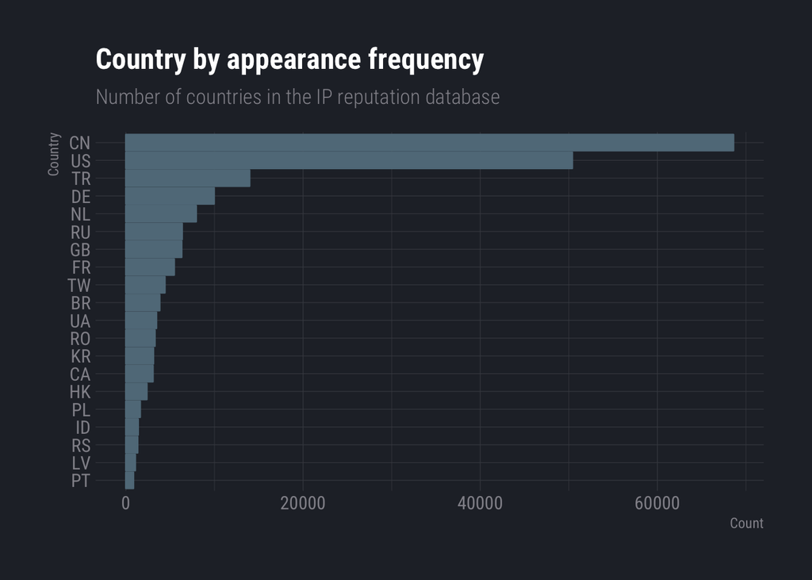

```r
library(ggplot2)
library(hrbrthemes)

# get top 20 countries
top_countries <- names(table(ipaddr$Country)[1:20])

ggplot(data=subset(ipaddr, Country %in% top_countries),
       aes(x=reorder(Country, Country, length))) +
  geom_bar() +
  coord_flip() +
  labs(title="Country by appearance frequency",
       subtitle="Number of countries in the IP reputation database",
       x="Country", y="Count") +
  theme_ft_rc()
```

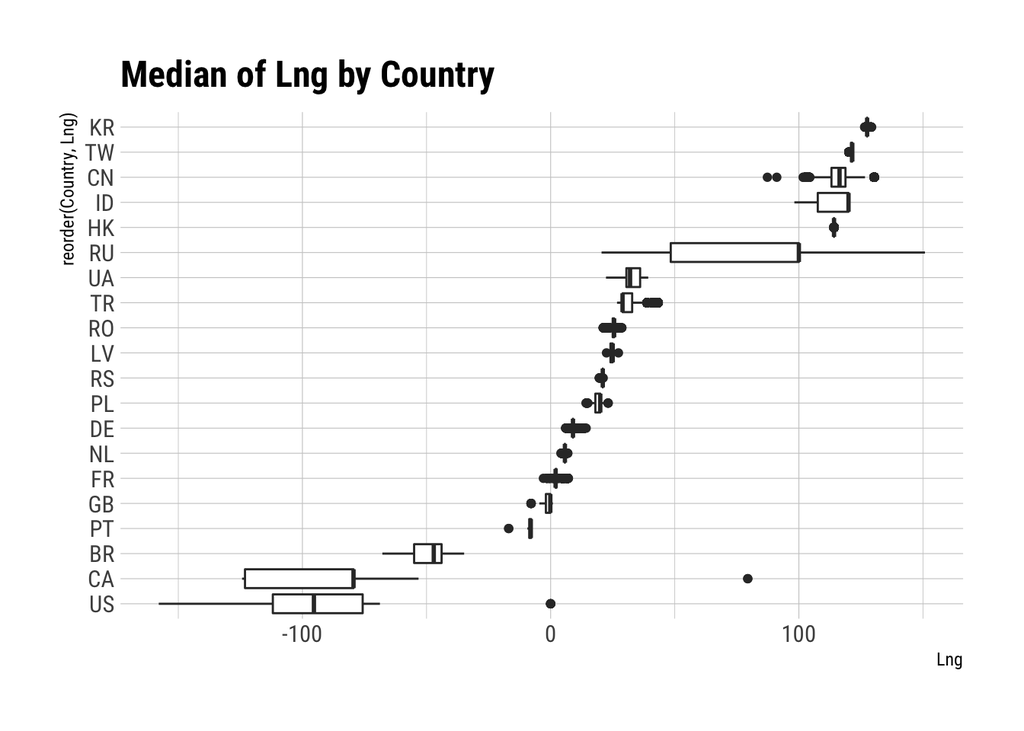

```r
ggplot(data=subset(ipaddr, Country %in% top_countries),
       aes(x=reorder(Country, Lng), y=Lng)) +
  geom_boxplot() +
  coord_flip()+
  labs(title="Median of Lng by Country")+
  theme_ipsum_rc()
```

An IPv4 address consists of 32 bits. This becomes clear when you convert the decimal notation into the binary equivalent: 201.105.7.34 corresponds to 11001001 01101001 00000111 00100010. In our dataset, our each of the IP address is also given a score on its Risk and Reliability:

```
##      Reliability      1      2      3      4      5      6      7      8      9     10
## Risk
## 1                     0      0     16      7      0      8      8      0      0      0
## 2                   804 149114   3670  57653      4   2084     85     11    345     82
## 3                  2225      3   6668  22168      2   2151    156      7    260     79
## 4                  2129      0    481   6447      0    404     43      2     58     24
## 5                   432      0     55    700      1    103      5      1     20     11
## 6                    19      0      2     60      0      8      0      0      1      0
## 7                     3      0      0      5      0      0      0      0      2      0
```

```
##    Risk Reliability Frequency
## 9     1           3        16
## 15    1           4         7
## 25    1           6         8
## 31    1           7         8
## 1     2           1       804
## 7     2           2    149114
```

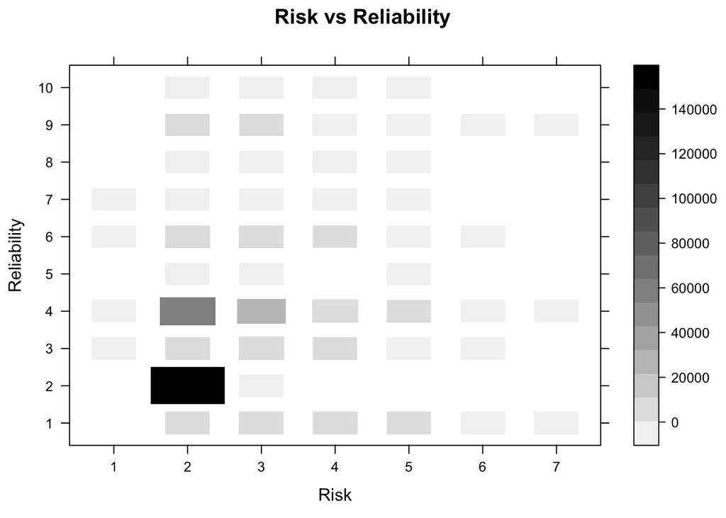

```
## # A tibble: 6 x 10
##   IP    Reliability  Risk Type  Country Locale   Lat    Lng x
##   <chr>       <int> <int> <chr> <fct>   <fct>  <dbl>  <dbl> <chr>
## 1 222.…           4     2 Scan… CN      Xiamen  24.5  118.  11
## 2 222.…           4     2 Scan… CN      Xiamen  24.5  118.  11
## 3 222.…           4     2 Scan… CN      Xiamen  24.5  118.  11
## 4 5.34…           6     3 Spam… US      <NA>    38    -97   12
## 5 178.…           4     5 Scan… UA      Merefa  49.8   36.1 11
## 6 66.2…           4     2 Scan… US      Union…  37.6 -122.  11
## # … with 1 more variable: simple_type <fct>
```

```
##   Risk Reliability Type Freq
## 1    1           1  C&C    0
## 2    2           1  C&C    0
## 3    3           1  C&C    0
## 4    4           1  C&C    1
## 5    5           1  C&C    2
## 6    6           1  C&C    1
```

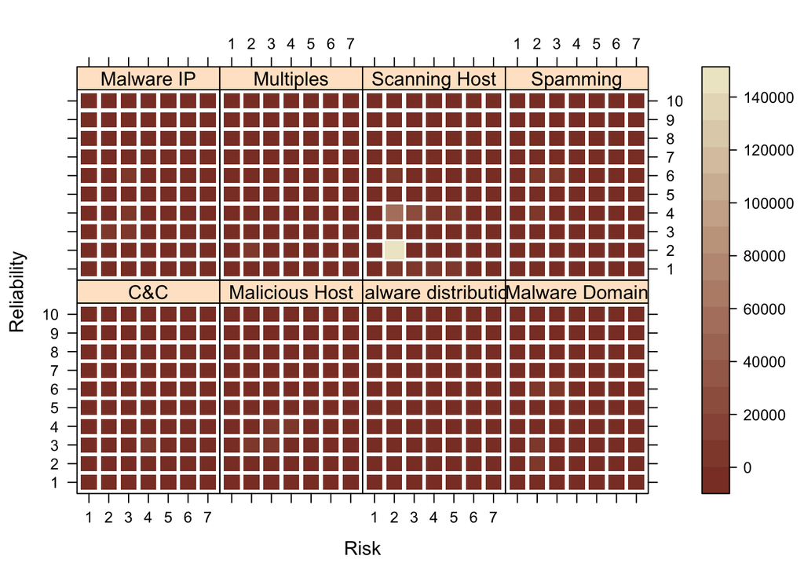

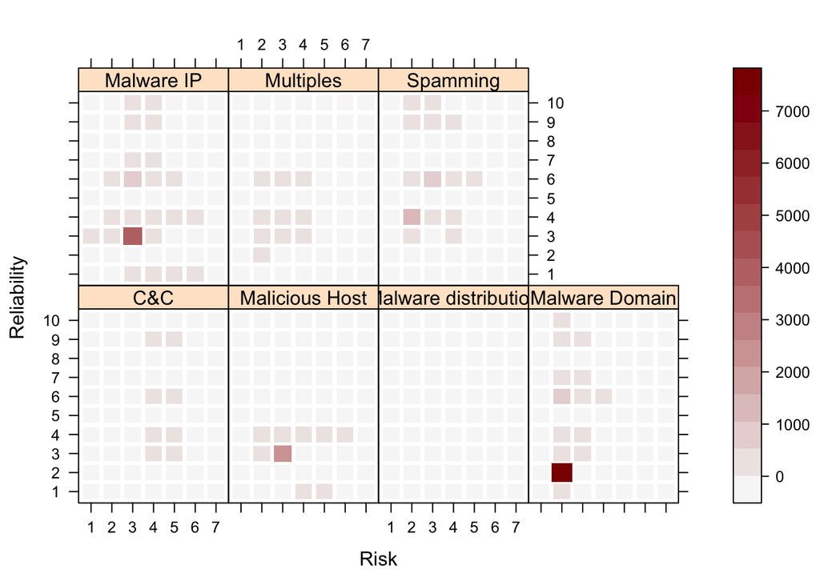

## 1.2 IP Addresses and Bits

### 1.2.1 About Bits

- A “bit” (binary digit) is atomic: it stores just a 0 or 1 and is the smallest unit of storage
- Anything with two separate states can store 1 bit
- A bit is too small to be much use, we typically group 8 bits to form 1 byte
- A byte (collection of 8 bits) look like this: 0110 1001
- One byte can store one character, e.g. “A” or “?” or “x”
- One byte can make 256 different patterns (and thus hold a number between 0 and 255), making it suitable for storing characters / letters
  - A is 65
  - B is 66
  - space is 32
  - `~` is 126
- 4 bytes can store numbers between -2147483648 and 2147483647
  - 2^(4*8)=4,294,967,296
- 8 bytes can store numbers between -9223372036854775808 and 9223372036854775807

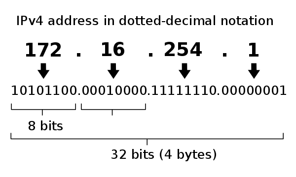

- IP addresses stored using the dotted-decimal range format goes from 0.0.0.0 to 255.255.255.255, which is 32 bits. In the possible address space, this means there is a total of 4,294,967,296 possible addresses (the maximum value of a 32-bit integer). This has a special significance: **Any IP addresses can be converted to/from a 32-bit integer value**. This is important because the integer representation saves both space and time and we can calculate some things easier with this representation than with a dotted-decimal form.
- If we perceive (or use a tool that perceives) IP addresses as a character, we are potentially wasting space by trading a 32-bit to 120-bit. We also trade away efficiency by using string comparison code versus integer arithmetic to accomplish some task.

### 1.2.2 About IP Addresses

- IP networks may be divided into subnetworks. For this reason, an IP address is recognized as consisting of two parts
  - The network prefix in the high-order bits
  - The remaining bits called the rest field used for host numbering within a network
- This original address definition means the first eight bits (octet) of the 32-bit address is the most important as it, being the network number field, specified the particular network a host was attached to. The remaining 24 bits uniquely identified a host connected to that network. This format was sufficient at a time when only a few large networks existed (since only the first octet specifies the network number, only 254 indepedent networks are supported at that time). This necessitates the introduction of address classes, and hence a new addressing architecture was introduced in 1981 as part of the specification of the Internet Protocol. This new architecture divides the address space into three classes (class A, B, C).
- The number of addresses usable is always $2^N-2$ where N is the number of bits. The subtraction of 2 adjusts for the use of the all-bits-zero host portion for network address and the all-bits-one host portion as a broadcast address
- The later versions of the IPv4 addressing system broadly separates IP addresses into 5 classes, which can be identified by the first octet of IP address. There are 4 octets so here by “first octet” we’re referring to the `127` in “127.100.100.0” (similarly, `0` is the fourth octet).

Classful addressing definition:

[output not shown]

- This architecture extended the addressing capability in the Internet but did not prevent IP address exhaustian. Many sites required larger address blocks than a Class C network provided ($2^{8}-2 = 254$) and thus receive a Class B block, rapidly depleting the availability of Class B addresses. Classful networking was replaced by **Classless Inter-Domain Routing (CIDR)** in 1993 to solve this problem.
- *n*: network ID
- *H*: host ID
- Class D and E not shown for brevity:

[output not shown]

### 1.2.3 Feature Engineering: IP Addresses to Integer and vice versa

We’re going to be making use of the `unlist` and `strsplit` functions to perform numerical computations on our IP addresses. Here’s a primer if you’re unfamiliar with the two functions:

```
## [1] "192" "168" "100" "0"
```

```
## [1] 192 168 100   0
```

We will also be using a left reduce function, which applies a function to the elements of a vector:

```
## [1] 460
```

```
## [1] 460
```

Combining these two, we can now write the IP to Integers function. Don’t worry about the functions from `bitops` for now:

```r
library(bitops)
# Define function for converting IP addresses to/from integers
# take an IP address string in dotted octets (e.g. 192.168.0.1)
# and convert it to a 32-bit long integer (3232235521)

ip2long <- function(ip){
  # convert string into vector of characters
  # 255.0.0.17 -> c(255, 0, 0, 17)
  ips <- unlist(strsplit(ip, ".", fixed=TRUE))
  # bit-shift, then "OR" the octets
  octet <- function(x, y){
    bitOr(bitShiftL(x,8), y)
  }
  Reduce(octet, as.integer(ips))
}

# take a 32-bit IP address (3232235521)
# and convert it to a dot notation
long2ip <- function(longip){
  # set up reversing bit manipulation
  octet <- function(nbits){
    bitAnd(bitShiftR(longip, nbits), 0xFF)
  }
  paste(Map(octet, c(24, 16, 8, 0)), sep="", collapse=".")
}
```

```
## [1] "192.168.0.1"
```

```
## [1] 3232235521
```

#### 1.2.3.1 Feature Engineering: Extract Classes from IP Addresses

In the context of classful IP Addresses, one may think of writing an extraction function to determine the class membership of an IP address based on what we’ve learned. However, to the extent that CIDR has rendered classful IP addresses obsolete. Protocols can no longer assume they can deduce the prfix length or subnet mask from the first part of the address; Instead, all prefix lengths are explicitly communicated: classless.

## 1.3 Classless Inter-Domain Routing (CIDR)

Recall that in the classful structure,

- Class A delegations contained 16777216 addresses each
- Class B delegations contained 65536 addresses each
- Class C delegations contained 256 addresses each

This was very inefficient for networks that didn’t fit these sizes. A network that needed 4096 addresses would either get sixteen Class C delegations (which would be bad for the global routing table because each of them would have to be routed separately: the class size was built into the protocol) or they would get one Class B delegation (which would waste a lot of addresses).

In 1993 CIDR was introduced. The protocols were adjusted to be able to deal with prefixes of different sizes and it became possible to route (both internally and externally) prefixes like a /30 or a /21 or a /15 etc etc. Anything between /0 and /32 became possible. Organisations that needed 16384 addresses could get a /18: exactly what they would need instead of the Class B delegation that consume 65,534 addresses.

CIDR encompasses the concept of variable-length subnet masking (VLSM) technique, which allows for the specification of arbitrary-length prefixes. CIDR introduced a new representation of IP addresses by prefixing an address with a suffix indicating the number of bits of the prefix, such as *192.0.2.0/24* for IPv4 and *2001:db8::/32* for IPv6. CIDR also introduces an administrative process of allocating address blocks to organizations based on their actual and short-term projected needs.

CIDR is **based on the idea of subnet masks**. A mask is placed over an IP address and creates a sub network: a network that is subordinate to the internet. The subnet mask signals to the router which part of the IP address is assigned to the hosts (the individual participants of the network) and which determines the network.

Instead of adding a subnet mask, a specification in the form of suffixes can also be integrated directly into the IP address using classless inter-domain routing. An integral fact pertaining CIDR is the concept of VLSM: the variable length subnet mask allows subnets to be realized with variable lengths and not only in size order of the network classes.

### 1.3.1 CIDR Notation

CIDR notation is a compact representation of an IP address and its associated routing prefix. The notation is constructed from an IP address, a slash (‘/’) character, and a decimal number. The number is the count of leading 1 bits in the subnet mask. Larger values here indicate smaller networks. The maximum size of the network is given by the number of addresses that are possible with the remaining, least-significant bits below the prefix.

- `192.168.100.14/24` represents the IPv4 address `192.168.100.14` and its associated routing prefix `192.168.100.0`, or equivalently, its subnet mask `255.255.255.0`, which has 24 leading 1-bits
- the IPv4 block `192.168.100.0/22` represents the 1024 IPv4 addresses from 192.168.100.0 to 192.168.103.255

### 1.3.2 Primer: Classful to classless domain routing infrastructure

An IP address has two components: - Network address  
- Host address

A subnest mask separates the IP address into the network and host address (). Subnetting further divides the **host** part of an IP address into a subnet and host address () if additional subnetworks are needed.

A subnet mask is referred to as such because it identifies network addresses of an IP addresses by performing a bitwise AND operation on the netmask.

```
##  [1] 0 0 1 1 0 0 1 0 1 1 1 1 1 1 0 1 1 0 0 0 1 1 0 1 1 1 0 0 0 1 0 0
```

```
##  [1] 1 1 1 1 1 1 1 1 1 1 1 1 1 1 1 1 0 0 0 0 0 0 0 0 0 0 0 0 0 0 0 0
```

```
##  [1] 0 0 1 1 0 0 1 0 1 1 1 1 1 1 0 1 0 0 0 0 0 0 0 0 0 0 0 0 0 0 0 0
```

A subnet mask is a 32-bit number that masks an IP address: it is made by setting network bits to all `1`s and setting host bits to all `0`s. Examples of commonly used netmasks for classed networks are 8-bits (Class A), 16-bits (Class B) and 24-bits (Class C), and classless networks are as follows:

[output not shown]

To see the conversion between binary to integers, we can use the `strtoi` function in R. For example, in the case of `/4` and `/5`, the respective binary addresses begin with:

```
## [1] 240
```

```
## [1] 248
```

From the examples above, we observe the CIDR notation written as the address of a network followed by a slash and ending with the bit-length of the prefix. `198.51.100.0/24` thus allocated 24 bits for the network prefix with the remaining 8 bits reserved for host addressing. In other words: addresses in the range of 198.51.100.0 to 198.51.100.255 belong to this subnet.

Subnet masks are also expressed in dot-decimal notation like an address. For example, 255.255.255.0 is the subnet mask for the prefix 198.51.100.0/24. Traffic is exchanged between subnetworks through routers when the routing prefixes of the source address and the destination address differ. A router serves as a logical or physical boundary between the subnets.

### 1.3.3 Why subnetting?

In the address allocation architecture of the Internet using CIDR and in large organizations, it is necessary to allocate address space efficiently. Subnetting may also enhance routing efficiency, or have advantages in network management when subnetworks are administratively controlled by different entities in a larger organization. Subnets may be arranged logically in a hierarchical architecture, partitioning an organization’s network address space into a tree-like routing structure.

Another advantage lies in security since all hosts in a subnetwork see all packets transmitted by any node in a network. In addition, performance of a network is adversely affected under heavy traffic load due to collisions and retransmissions.

We’ve learned that applying a subnet mask to an IP address separates network address from host address. The network bits are represented by the 1’s in the mask, and the host bits are represented by 0’s. When we apply the Class C subnet mask to the IP address 216.3.128.12, we get through the bit-wise AND operator:

IP: 1101 1000.0000 0011.1000 0000.0000 1100 (216.003.128.012) Mask: 1111 1111.1111 1111.1111 1111.0000 0000 (255.255.255.000)

Produces: 1101 1000.0000 0011.1000 0000.0000 0000 (216.003.128.000)

```
## [[1]]
## [1] 1 1 0 1 1 0 0 0
##
## [[2]]
## [1] 0 0 0 0 0 0 1 1
##
## [[3]]
## [1] 1 0 0 0 0 0 0 0
##
## [[4]]
## [1] 0 0 0 0 1 1 0 0
```

Another scenario where subnetting is used is one where a web host with a Class C network needing to divide the network such that parts of its network can be leased to its customers. Assuming that the network address given is 216.3.128.0 and the company wants to divide the network into 2: first half for internal usage and second half to its tenants / customers:  
- 216.3.128.(0000 0000): assigned to web host  
- 216.3.128.(1000 0000): assigned to customers

Subnet mask of 255.255.255.(1111 0000) / subnet mask of 255.255.255.240

```
## [1] 128
```

```
## [1] 144
```

```
## [1] 160
```

The classful address scheme (Class A, B and C) of allocating IP addresses in 8-bit increments can be very wasteful. With classful IP addressing, a minuimum number of IP addresses allocated to any organization is 256 (Class C). When a company only requires 15 but receive 256 addresses, waste is incurred. An organization that requires more than 256 (for example, 500) is assigned a Class B, which allocates 65,536 and an organization that is assigned Class A is allocated 16.8 million IP addresses.

With CIDR, a network of IP addresses is allocated in 1-bit increments as opposed to 8-bits in classful network. The use of a CIDR notated address can easily represent classful addresses (Class A = /8, Class B = /16, and Class C = /24). The number next to the slash (i.e. /8) represents the number of bits assigned to the network address.

When we’re performing CIDR-based analyses, a common task is to determine whether an address falls within a given CIDR range. In R code, we are converting both the IP address and network block address to integer then performing the necessary bitwise operations to see if they do match up.

```r
ip_in_cidr <- function(ip, cidr){
 long_ip <- ip2long(ip)
 cidr_parts <- unlist(strsplit(cidr, "/"))
 cidr_range <- ip2long(cidr_parts[1])
 cidr_mask <- bitShiftL(bitFlip(0),
                        (32-as.integer(cidr_parts[2]))
                        )
 return(bitAnd(long_ip, cidr_mask) == bitAnd(cidr_range, cidr_mask))
}

ip_in_cidr("10.0.1.15", "10.0.1.3/24")
```

```
## [1] TRUE
```

```r
ip_in_cidr("10.0.1.15", "10.0.2.255/24")
```

```
## [1] FALSE
```

## 1.4 Autonomous System Number (ASN) and BGP (border gateway protocol)

With CIDR, blocks of addresses can be treated as groups of nodes: we can use them to identify network packets (incoming or outgoing traffic) and therefore classify groups of malicious / legitimate nodes. A machine learning engineer can then use these groupings to dig into the data and relationships and extract potential features.

Furthermore, once we are familiar with the CIDR prefix format, we can see how those prefixes are grouped and defined as an autonomous system (AS). An AS is a fancy term but what it really mean **is a collection of connected Internet Protocol (IP) routing prefixes** under the control of one or more network operators on behalf of a single administrative entity that presents a common and clearly defined routing policy to the internet.

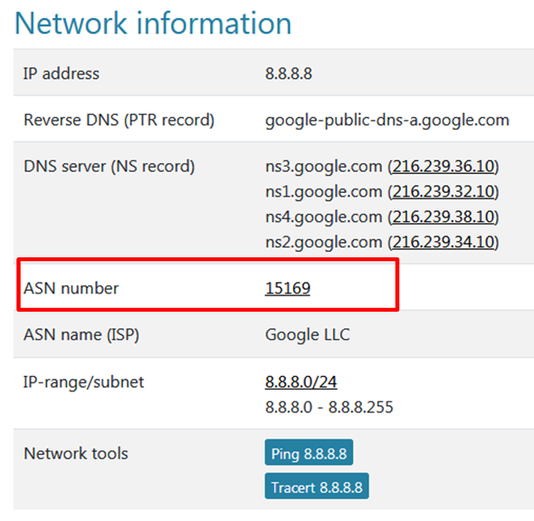

Originally the definition required control by a single entity, typically an ISP or a very large organization with independent connections to multiple networks, that adhered to a single routing policy. That ISP must have an officially registered **autonomous system number** (ASN). A unique ASN is allocated to each AS and uniquely identifies each network on the internet. ASN are assigned in blocks by IANA to regional internet registries (RIRs) and the RIR in turn assign ASNs to entities within its designated area from the block assigned by IANA.

> These Autonomous Systems must have an officially registered autonomous system number (ASN), which they get from their Regional Internet Registry: AFRINIC, ARIN, APNIC, LACNIC or RIPE NCC

A newer definition came into use because multiple organizationscan run Border Gateway Protocol (BGP) using private AS numbers to an ISP that connects all those organizations to the internet. BGP is a protocol designed to exchange routing and reachability information among autonomous systems (AS) on the internet; it makes routing decisions based on paths, network policies or rule-sets configured by a network administrator and is involved in making core routing decisions.

> A unique ASN (AS Number) is allocated to each AS for use in BGP routing. AS numbers are important because the ASN uniquely identifies each network on the Internet.

## 1.5 `ggplot2` Visualization of malicious nodes

Taking a peek at the dataset:

```
##            IPAddr Reliability Risk          Type Country Locale     LAT
## 4     5.34.246.67           6    3      Spamming      US        38.0000
## 10  174.142.46.19           6    3      Spamming                24.4798
## 16 112.216.121.87           4    3 Scanning Host      KR        37.0000
## 17 112.216.121.78           4    3 Scanning Host      KR        37.0000
## 18 112.216.121.77           4    3 Scanning Host      KR        37.0000
## 19 112.216.121.75           4    3 Scanning Host      KR        37.0000
##         LNG
## 4  -97.0000
## 10 118.0819
## 16 127.5000
## 17 127.5000
## 18 127.5000
## 19 127.5000
```

```
##
##            C&C Malicious Host     Malware IP  Scanning Host       Spamming
##            463           3180           5782          31854           1291
```

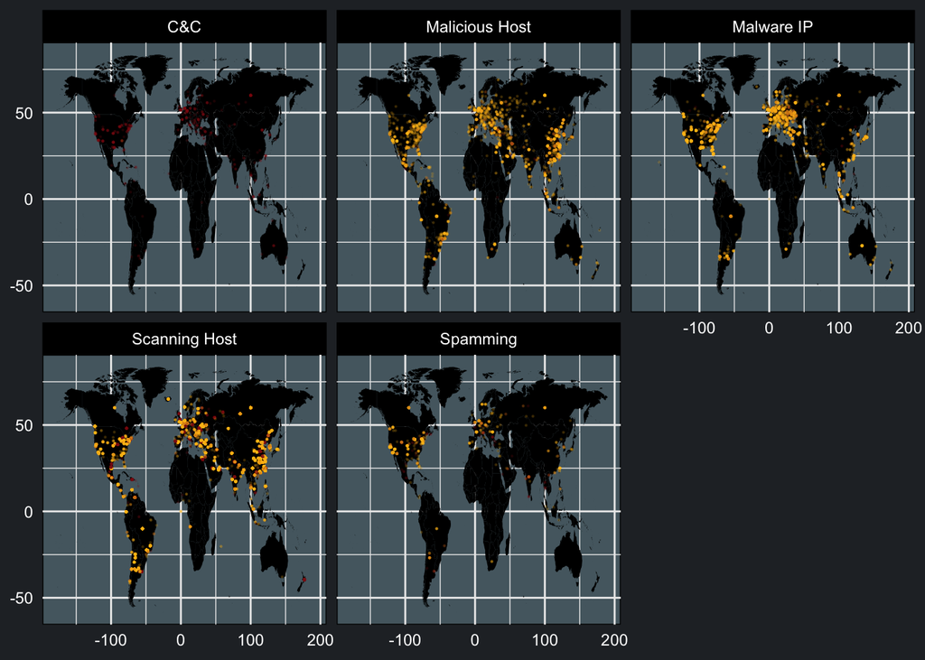

### 1.5.1 Peers and Best Path

When two routers have established connection for exchanging BGP information, they are referred to as BGP peers. Such BGP peers exchange routing information between them via BGP sessions that run over TCP, which is a reliable, connection oriented & error free protocol.

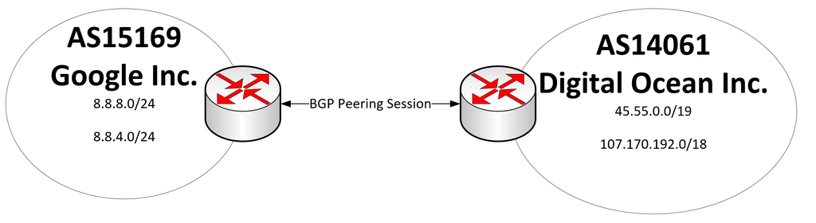

Once the BGP Session is established, the routers can advertise a list of network routes that they have access to and will scrutinize them to find the route with the shortest path. BGP doesn’t make sense when a peer is connected only to one other peer because that peer is always going to be the best and only path to other networks. When a network is connected to multiple peers then certain paths will be shorter, faster or more reliable than others. Google’s AS15169 peers with [265 other IPv4 peers](https://bgpview.io/asn/15169) one of which is Digital Ocean Inc.’s AS14061. Both are connected to other ISPs on the internet, but since they are peers they can also exchange routing information, giving routers within their network a shorter path of connectivity. If the neighborship is broken, their routers can re-arrange their routing tables to connect with other Autonomous Systems through other peers / AS.

Because of the relationship between ASN and BGP, it’s possible to know the adjacent neighbors of each AS; if one AS “neighborhood” is rife with malicious nodes or suspicious activity it might a leading indicator that autonomous systems around it are also harboring malicious traffic.

For comparison, if we refer to the DNSlytics for [as14061: Digital Ocean](https://dnslytics.com/bgp/as14061) and compare it against [as7393: Cybercon](https://dnslytics.com/bgp/as7393), we can get some quick summary of the IPs that are hosted on each AS. Notice that, for example, the number of spam domains hosted on as14061 is 1101-to-1 for example as compared to 8669-to-1.

```
##                                Variables      as14061   as7393
## 1                               Assignee DigitalOcean Cybercon
## 2               Number of domains hosted    1,667,967   52,014
## 3         Number of adult domains hosted        5,636      754
## 4          Number of name servers hosted       70,825    1,449
## 5            Number of SPAM hosts hosted        1,515        6
## 6          Number of open proxies hosted          195        0
## 7          Number of mail servers hosted      223,061   27,664
## 8           Number of IDN domains hosted        1,620        0
## 9 Number of domains in Alexa top million       17,939      500
```

# 2 Chapter 2: Exploratory Data Analysis on IP Addresses

In the following chapter, we’ll draw upon lessons from traditional exploratory data analysis and visual exploration techniques to help us in our process of insight discovery.

In the following subsection, we’ll start by augmenting our data with additional meta-data from the IANA IPv4 Address Space Registry. The dataset we’ll read in represent a high level grouping of IPv4 address space registry allocations - although it should be said that most of the registrants are not responsible for the activities of individual nodes. We’ll use this extra information for what it’s intended: to set up further investigations.

## 2.1 Augmenting IP Address with Address Space data

```
##   Prefix                 Designation    Date           WHOIS
## 1  000/8 IANA - Local Identification 1981-09
## 2  001/8                       APNIC 2010-01 whois.apnic.net
## 3  002/8                    RIPE NCC 2009-09  whois.ripe.net
## 4  003/8        Administered by ARIN 1994-05  whois.arin.net
## 5  004/8         Level 3 Parent, LLC 1992-12  whois.arin.net
## 6  005/8                    RIPE NCC 2010-11  whois.ripe.net
##                                                          RDAP Status..1.
## 1                                                               RESERVED
## 2                                     https://rdap.apnic.net/  ALLOCATED
## 3                                   https://rdap.db.ripe.net/  ALLOCATED
## 4 https://rdap.arin.net/registryhttp://rdap.arin.net/registry     LEGACY
## 5 https://rdap.arin.net/registryhttp://rdap.arin.net/registry     LEGACY
## 6                                   https://rdap.db.ripe.net/  ALLOCATED
##   Note
## 1  [2]
## 2
## 3
## 4
## 5
## 6
```

Cleaning up `iana$Prefix` since it uses the old/BSD-number formatting (allows leading zeros and we don’t need to know the CIDR component):

```r
iana$Prefix <- sub(pattern = "^(00|0)", replacement="", x = iana$Prefix, perl = TRUE)
iana$Prefix <- sub(pattern = "/8$", replacement="", x = iana$Prefix, perl = TRUE)
tail(iana)
```

```
##     Prefix Designation    Date WHOIS RDAP Status..1.     Note
## 251    250  Future use 1981-09              RESERVED     [16]
## 252    251  Future use 1981-09              RESERVED     [16]
## 253    252  Future use 1981-09              RESERVED     [16]
## 254    253  Future use 1981-09              RESERVED     [16]
## 255    254  Future use 1981-09              RESERVED     [16]
## 256    255  Future use 1981-09              RESERVED [16][17]
```

Next, we want to extract just the prefix from the original AlienVault list of IP addresses. We do this using `sub` to perform replacement on all characters from the first “.” and onwards:

```r
data$IPPrefix <- sub("\\..*","", data$IPAddr)
head(data$IPPrefix,10)
```

```
##  [1] "222" "222" "222" "5"   "178" "66"  "222" "222" "222" "174"
```

We’ll now create a `Designation` variable by assigning the appropriate value of `iana$Designation` based on the `data$IPPrefix` values:

```r
data$Designation <- sapply(data$IPPrefix, function(ip){
  iana[iana$Prefix == ip, "Designation"]
})

summary(data$Designation, maxsum=8)
```

```
##                    APNIC                 RIPE NCC                     ARIN
##                    93776                    74789                    42358
##                   LACNIC     Administered by ARIN Administered by RIPE NCC
##                    18914                    18008                     5893
##    Administered by APNIC                  (Other)
##                     2615                     2273
```

Quickly compare the distribution of registry present in our dataset against that of the external IANA data:

```r
combined_Designation <- merge(
  data.frame(table(data$Designation)),
  data.frame(table(iana$Designation)), by = "Var1"
)

colnames(combined_Designation) <- c("Registry", "AlienVault_Count", "IANA_Count")

head(combined_Designation[order(combined_Designation$IANA_Count, decreasing = TRUE), ],8)
```

```
##                 Registry AlienVault_Count IANA_Count
## 3   Administered by ARIN            18008         55
## 8                  APNIC            93776         45
## 10                  ARIN            42358         36
## 30              RIPE NCC            74789         35
## 21            Future use                0         16
## 27             Multicast                0         16
## 25                LACNIC            18914          9
## 2  Administered by APNIC             2615          6
```

We can compute correlation between the number of malicious nodes attributed to a registry (`AlienVault_Count`) and the number of assigned network blocks from our IANA data. It makes sense that there would be more malicious nodes in larger groups of assigned network blocks.

```
## [1] 0.6898625
```

By default, the `cor()` computes the correlation using the “pearson” method, but we could as well have specified the method to be “spearman” or “kendall”.

### 2.1.1 Correlation Methods

The different values for our `method` parameter corresponds to the different correlation methods:  
- `pearson`: $\frac{\sum{(x-\bar{x})(y-\bar{y})}}{\sqrt{\sum{(x-\bar{x})^2 \sum{(y-\bar{y})^2}}}$ or alternatively: cov(x,y)/(sd(x)*sd(y)) - `spearman`: $R_s = 1-(\frac{6\sum{d}^2}{n^3-n})$ where $d^2$ is the squared difference between the ranks of two values and *n* is the number of observations  
- `kendall`: not discussed in details here, but refers to Kendall’s Tau (Kendall’s Rank Correlation)

# 3 Chapter 3: Graph-based EDA

For this chapter, we’ll work with the ZeuS botnet malware. It is a crimeware kit that steals credentials from online services like social networks, online banking accounts, FTP accounts, email accounts and other (phishing). Our data is gathered from the [ZeuS tracker site](https://zeustracker.abuse.ch), and carries the following description:

> This blocklist contains the same data as the ZeuS IP blocklist (BadIPs) but with the slight difference that it doesn’t exclude hijacked websites (level 2) and free web hosting providers (level 3). This means that this blocklist contains all IPv4 addresses associated with ZeuS C&Cswhich are currently being tracked by ZeuS Tracker. Hence this blocklist will likely cause some false positives.

```
##               IP
## 1 101.200.81.187
## 2  103.19.89.118
## 3 103.230.84.239
## 4   103.4.52.150
## 5   103.7.59.135
## 6 104.247.219.41
```

## 3.1 Network intelligence-based Preprocessing

In the following section, we will be using some preprocessing functions from the `netintel` library and also some custom functions:

To see a few of the functions at work, we’ll try with `BulkOrigin` which retrieves the BGP Origin ASN for a list of IPv4 addresses:

```r
BulkOrigin("182.253.162.193")
```

```
##      AS              IP       BGP.Prefix CC Registry  Allocated
## 1 17451 182.253.162.193 182.253.162.0/24 ID    apnic 2010-05-10
##                            AS.Name
## 1 BIZNET-AS-AP BIZNET NETWORKS, ID
```

Another example is the `BulkOriginASN` which retrieves BGP Origin ASN info for a list of ASN ids:

```r
BulkOriginASN("AS17451")
```

```
##      AS CC Registry  Allocated                          AS.Name
## 1 17451 ID    apnic 2000-11-07 BIZNET-AS-AP BIZNET NETWORKS, ID
```

We can also retrieve BGP Peer ASN info for a list of IP addresses:

```r
BulkPeer("182.253.162.193")
```

```
##   Peer.AS              IP       BGP.Prefix CC Registry  Allocated
## 1    6453 182.253.162.193 182.253.162.0/24 ID    apnic 2010-05-10
## 2    6939 182.253.162.193 182.253.162.0/24 ID    apnic 2010-05-10
## 3   58463 182.253.162.193 182.253.162.0/24 ID    apnic 2010-05-10
## 4  196844 182.253.162.193 182.253.162.0/24 ID    apnic 2010-05-10
##                                                                       Peer.AS.Name
## 1                                   AS6453 - TATA COMMUNICATIONS (AMERICA) INC, US
## 2                                           HURRICANE - Hurricane Electric LLC, US
## 3                               PGASCOM-AS-AP PT.PGAS TELEKOMUNIKASI NUSANTARA, ID
## 4 PIONIER-AS-AMS-IX PIONIER, National Research and Education Network in Poland, PL
```

Applying that function on `zeus$IP`, we obtain a data frame in return:

```r
origin <- BulkOrigin(zeus$IP)
head(origin)
```

```
##       AS             IP       BGP.Prefix CC Registry  Allocated
## 1  37963 101.200.81.187   101.200.0.0/16 CN    apnic 2011-01-24
## 2 132717  103.19.89.118   103.19.89.0/24 IN    apnic 2013-03-28
## 3 132717 103.230.84.239  103.230.84.0/24 IN    apnic 2014-04-29
## 4  46062   103.4.52.150    103.4.52.0/24 ID    apnic 2011-05-19
## 5 131447   103.7.59.135    103.7.56.0/22 TH    apnic 2012-03-15
## 6  46261 104.247.219.41 104.247.216.0/21 US     arin 2014-12-09
##                                                             AS.Name
## 1 CNNIC-ALIBABA-CN-NET-AP Hangzhou Alibaba Advertising Co.,Ltd., CN
## 2    NDCTPL-IN NxtGen Datacenter & Cloud Technologies Pvt. Ltd., IN
## 3    NDCTPL-IN NxtGen Datacenter & Cloud Technologies Pvt. Ltd., IN
## 4                      LINTASBUANA-AS-ID PT. BUANA LINTAS MEDIA, ID
## 5                        POP-IDC-TH POPIDC powered by CSLoxinfo, TH
## 6                                QUICKPACKET - QuickPacket, LLC, US
```

### 3.1.1 Working with `igraph`

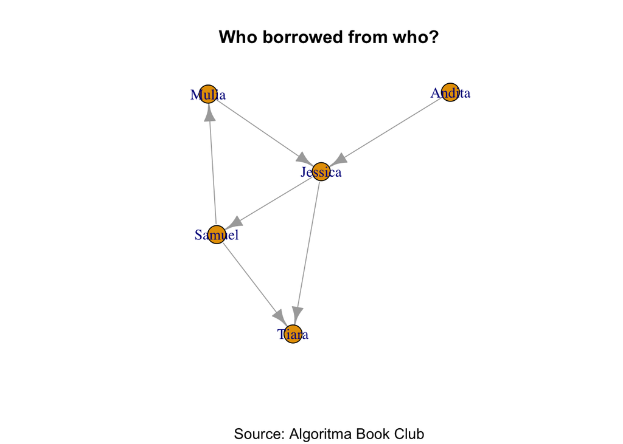

```r
suppressPackageStartupMessages(library(igraph))
bookclub <- graph(edges=c("Samuel", "Mulia", "Mulia", "Jessica", "Jessica", "Samuel",
                          "Andita", "Jessica", "Jessica", "Tiara", "Samuel", "Tiara"),
                    directed = TRUE)
plot(bookclub)
title(main = "Who borrowed from who?", sub = "Source: Algoritma Book Club")
```

In “graph language”, vertex is a synonym for a node: the common point of two line segment. Edges (lines) are what connect two nodes in a network. In the following exercise, we’ll create a simple graph using the `igraph` package.

The graph (visualized):

[figure not shown]

# 4 Bonus Content

## 4.1 `dplyr` system

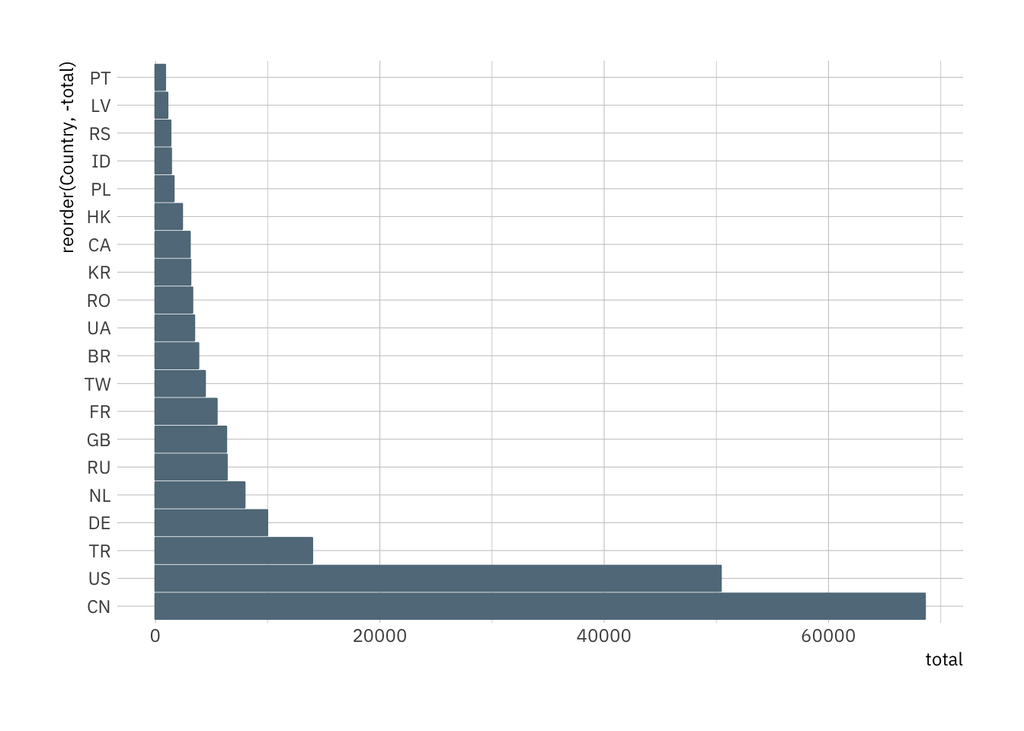

## 4.2 Level Plots in base R, `lattice` and `ggplot2`

From the `elevation` dataset, we multiply the `x` and `y` by 50 (help documentation say the coordinates are in multiples of 50 feet) and `z` by 10 (help documentation say the elevations are in multiples of 10). Rather than plotting the individual values what we would do instead is to create a surface that covers the whole grid region using the loess function. This function fits a local polynomial trend surface using weighted least squares to approximate the elevation across the whole region. The function for a local quadratic surface is:

We will then create a grid region that goes from 10 to 300 feet in both the x and y directions:

Use our loess model to predict and fill the grid. Notice that `z` is a matrix with two dimensions (`x` and `y` respectively):

Now use `image()` to see how our loess model fill the grid with its fitted value. Adjust the `span` to be 0.7 or higher and then re-run the exercise to see how our fitted values are smoother:

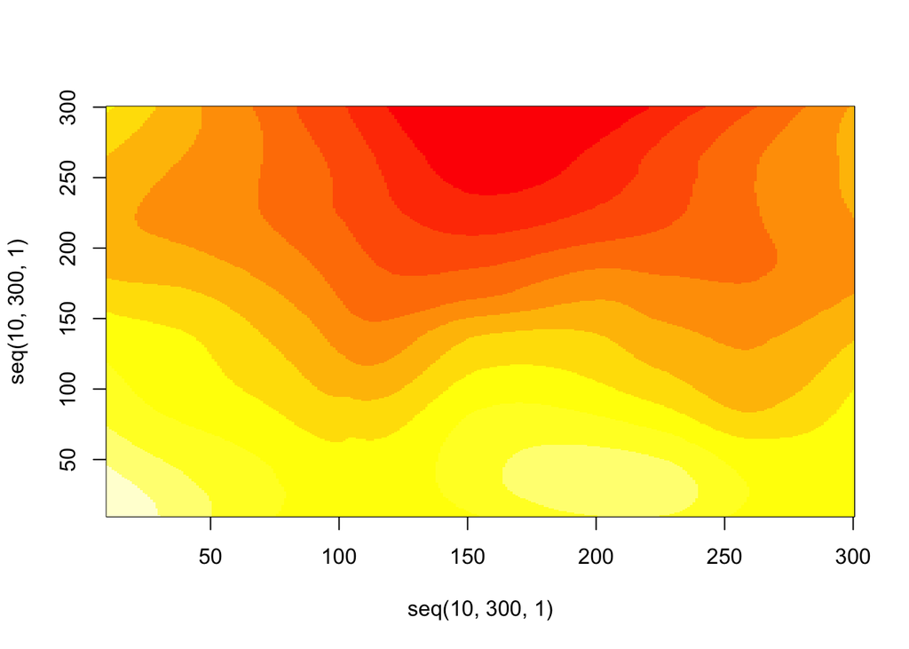

As a comparison, take a look at the fitted values when we use a linear model instead of our loess model:

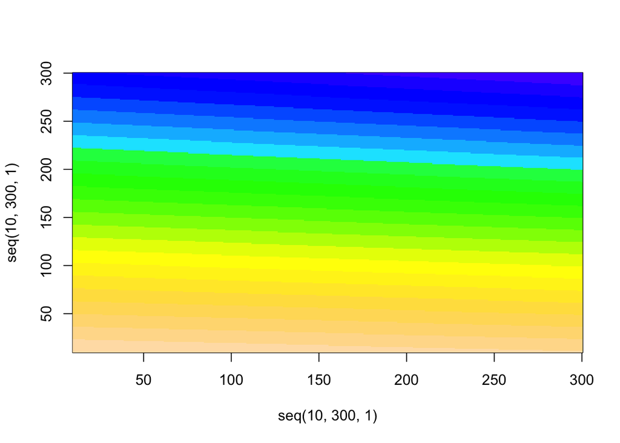

Instead of creating a colored grid using `image()`, we can use `levelplot` from lattice:

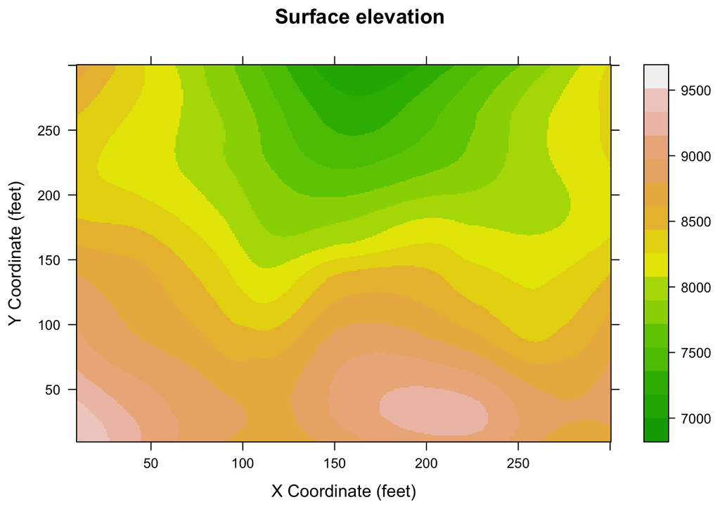

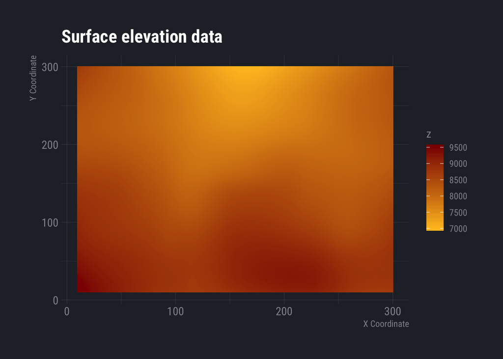

Data on soya bean production in a uniformity trial measured at plots of size 5x5 meters and other soil properties measured in points given by the data coordinates. `X` and `Y` variable refers to the respective coordinates, `PH` is the soil PH value, `K` is the potassium content and `PROD` is production converted to productivity by a unit of area - hectare (ton/ha):

```
##      X   Y   P  PH    K    MO    SB iCone   Rend PROD
## 1  5.6 3.6 4.4 6.3 0.53 47.52 80.63  31.0 6.3980 2.56
## 2 15.2 1.6 3.7 6.3 0.38 48.74 82.23  29.5 7.0502 2.82
## 3 24.8 4.6 3.5 5.4 0.47 51.79 61.47  23.0 5.8848 2.35
## 4 34.4 5.6 3.9 5.2 0.48 57.88 59.09  24.5 8.5182 3.41
## 5 44.0 1.6 3.6 5.6 0.52 59.70 71.61  18.5 7.4749 2.99
## 6 53.6 1.6 3.7 5.2 0.45 53.61 56.98  21.5 9.3160 3.73
```

### 4.2.1 Importance of visuals in EDA

Anscombe (1973) has a nice example where he uses a constructed dataset to emphasize the importance of using graphs in statistical analysis. The data is built into R:

```
##   x1 x2 x3 x4   y1   y2    y3   y4
## 1 10 10 10  8 8.04 9.14  7.46 6.58
## 2  8  8  8  8 6.95 8.14  6.77 5.76
## 3 13 13 13  8 7.58 8.74 12.74 7.71
## 4  9  9  9  8 8.81 8.77  7.11 8.84
## 5 11 11 11  8 8.33 9.26  7.81 8.47
## 6 14 14 14  8 9.96 8.10  8.84 7.04
```

```
## # A tibble: 4 x 6
##   set   `mean(x)` `sd(x)` `mean(y)` `sd(y)` `cor(x, y)`
##   <chr>     <dbl>   <dbl>     <dbl>   <dbl>       <dbl>
## 1 1             9    3.32      7.50    2.03       0.816
## 2 2             9    3.32      7.50    2.03       0.816
## 3 3             9    3.32      7.5     2.03       0.816
## 4 4             9    3.32      7.50    2.03       0.817
```

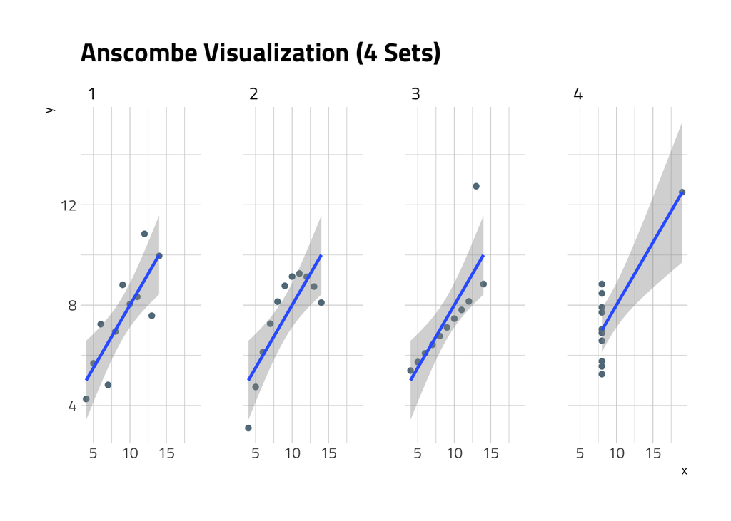

Notice that all the four sets have the same statistical properties and even the same regression coefficients; A visual exploration however surfaced 4 very different pattern within each dataset.

### 4.2.2 Exercise:

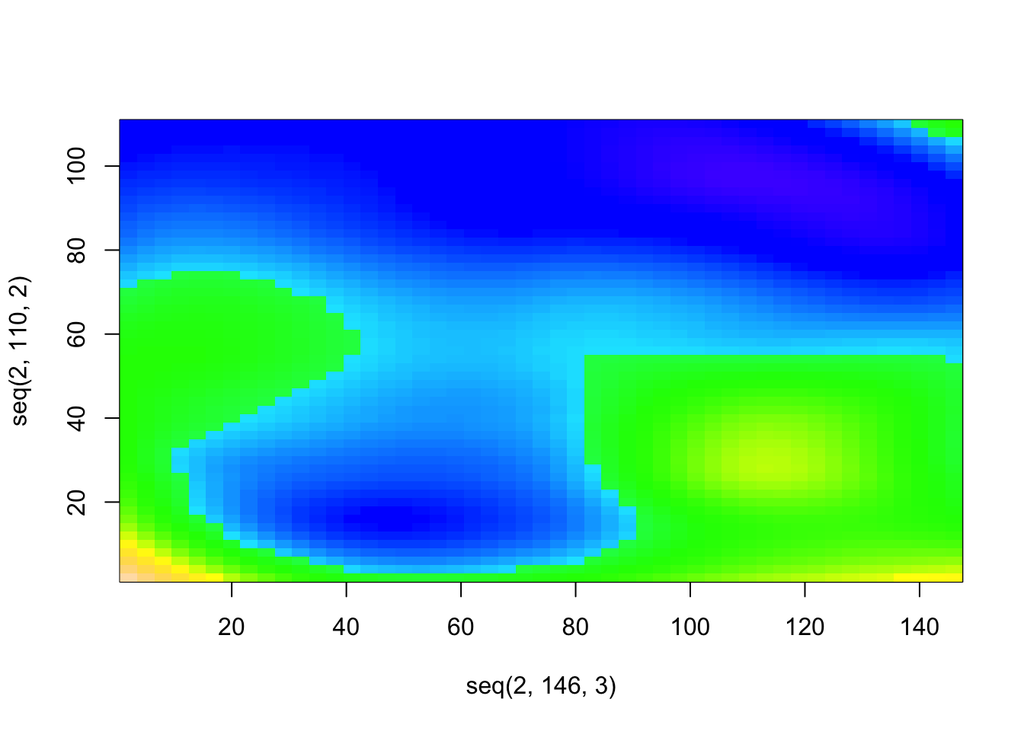

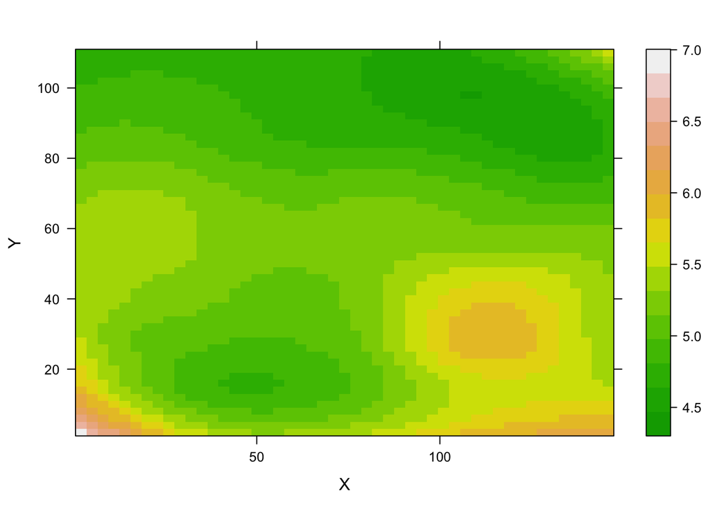

```
##  [1] "greenyellow"          "lightgoldenrodyellow" "lightyellow"
##  [4] "lightyellow1"         "lightyellow2"         "lightyellow3"
##  [7] "lightyellow4"         "yellow"               "yellow1"
## [10] "yellow2"              "yellow3"              "yellow4"
## [13] "yellowgreen"
```

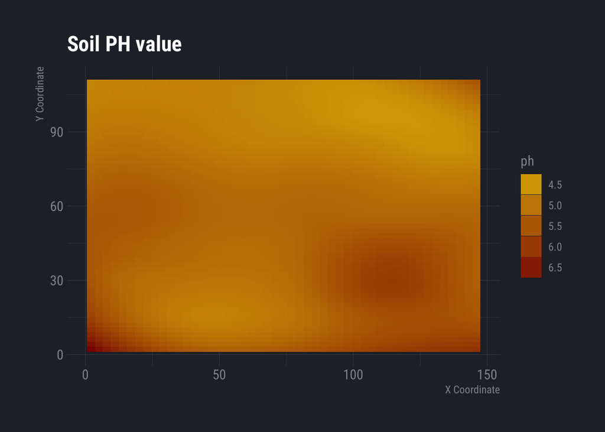

Primer on Left Shift and Right shift

```r
strtoi(00000111, base = 2)
```

```
## [1] 7
```

```r
strtoi(00001110, base = 2)
```

```
## [1] 14
```

```r
bitShiftL(7,1)
```

```
## [1] 14
```

```r
strtoi(01000011, base = 2)
```

```
## [1] 67
```

```r
# shift the bits to left by 1
strtoi(10000110, base = 2)
```

```
## [1] 134
```

```r
bitShiftL(67, 1)
```

```
## [1] 134
```

```r
# # shift the bits to left by 2
strtoi(100001100, base = 2)
```

```
## [1] 268
```

```r
bitShiftL(67, 2)
```

```
## [1] 268
```

```r
toDotNotation(268)
```

```
## [1] 0 0 0 0 1 1 0 0
```

```r
toDotNotation(12)
```

```
## [1] 0 0 0 0 1 1 0 0
```

```r
toDotNotation(255)
```

```
## [1] 1 1 1 1 1 1 1 1
```

BGP in Indonesia: https://dnslytics.com/bgp/id